# Überprüfung der Datenausschnitte

Hier soll eine Überprüfung der Trackausschnitte stattfinden, weil die aktuellen Ausschnitte so ausehen, als wären sie nicht richtig zentriert.

Dafür laden wir zunächst einen Beispiel-HACI-Track, führen die Parallaxenkorrektur durch und sehen ind vergleichen die Ausschnitte mit den bereits gespeicherten.

```python
import numpy as np
import pandas as pd
import xarray as xr

from standard_config import *
haci_bbox_path = "{}/HACI_bbox_data/".format(local_data_path)
radar_track_path = "{}/radar_track/radar_tracks/unkorrigiert/".format(local_data_path)
track_data_path = "{}/radar_track/trackdata/unkorrigiert/".format(local_data_path)

import datetime as dt
import l15_msevi.msevi as msv

from io_tools import radolan
from analysis_tools import grid_and_interpolation as gi
from analysis_tools import parallax as px

from scipy import ndimage as ndi
import skimage

import matplotlib.pyplot as plt
%matplotlib inline

import geooperations as go

import sys
sys.path.append("/vols/talos/home/stephan/utils/")
import msg_coord_conv as mcc
```

Als nächstes laden wir uns ein Beispiel und sehen uns dessen Daten an.

```python
track_id = "20130620_140"

haci_bbox_data = pd.read_table("{}haci-{}-{}-{}-bbox.dat".format(haci_bbox_path,
                                                                 track_id[0:4],
                                                                 track_id[4:6],
                                                                 track_id[6:8]),
                               sep='\s+')

radar_track_data = pd.read_csv("{}track_{}.csv".format(radar_track_path,track_id))
track_data = xr.open_dataset("{}haci_trackdata_{}.nc".format(track_data_path,track_id))
```

Dann laden wir uns mal den Startpunkt des HACI-Tracks.

```python
haci_track = haci_bbox_data.iloc[int(track_id[-3:])-1]
```

```python
haci_track
```

```
date     2013-06-20
time          02:55
id              140
flags             0
t0               35
t1               41
l00             535
l01             540
c00             561
c01             569
l0              535
l1              549
c0              560
c1              574
Name: 139, dtype: object
```

Damit hätten wir die Koordinaten im Radolangitter. Um sie in das MSG-Gitter umzuwandeln, brauchen wir sie als geodätische Koordinaten.

```python
r = radolan.Radolan()
```

```python
lon00 = r.lon[haci_track.l00,haci_track.c00]
lat00 = r.lat[haci_track.l00,haci_track.c00]
lon01 = r.lon[haci_track.l01,haci_track.c01]
lat01 = r.lat[haci_track.l01,haci_track.c01]

print lon00, lat00, lon01, lat01
```

```
10.521552681453274 51.73379938817003 10.633464995798372 51.776132305824994
```

```python
l_punkt =  haci_track.l00 + (haci_track.l01 - haci_track.l00) / 2
c_punkt =  haci_track.c00 + (haci_track.c01 - haci_track.c00) / 2
```

```python
punkt_lon = r.lon[l_punkt,c_punkt]
punkt_lat = r.lat[l_punkt,c_punkt]
```

Als nächstes laden wir uns die MSG-Koordinatenreferenz.

```python
msg_lon,msg_lat = msv.MSGtools.get_msg_lon_lat('eu')
```

Und suchen uns die Koordinaten, die zu den geodätischen Kooridnaten des Radarpunktes gehören.

```python
r_radar,c_radar = gi.get_index((lon00,lat00),msg_lon,msg_lat)
print "r = {}, c= {}".format(r_radar,c_radar)
```

```
r = 153, c= 522
```

Dann laden wir uns die Satellitendaten für den Startzeitpunkt und erzeugen einen Ausschnitt.

```python
date = haci_track.date.split("-")
time = haci_track.time.split(":")

t_start = dt.datetime(int(date[0]),int(date[1]),int(date[2]),
                      int(time[0]),int(time[1]))
```

```python
t_start
```

```
datetime.datetime(2013, 6, 20, 2, 55)
```

```python
sat_channels = ['IR_108']
s  =msv.MSevi(time=t_start,chan_list=sat_channels)
s.rad2bt()
```

```
Region suggests use of hdf file
```

```python
r = radolan.Radolan()
r.read_nc(t_start)
```

```python
box_size = 25
cutout = s.bt['IR_108'][r_radar-box_size:r_radar+box_size,
                        c_radar-box_size:c_radar+box_size]

lon_cutout = msg_lon[r_radar-box_size:r_radar+box_size,
                     c_radar-box_size:c_radar+box_size]

lat_cutout = msg_lat[r_radar-box_size:r_radar+box_size,
                     c_radar-box_size:c_radar+box_size]
```

```python
cutout_radar = r.data[haci_track.l00-box_size*6:haci_track.l00+box_size*6,
                      haci_track.c00-box_size*3:haci_track.c00+box_size*3]

rlon_cutout = r.lon[haci_track.l00-box_size*6:haci_track.l00+box_size*6,
                    haci_track.c00-box_size*3:haci_track.c00+box_size*3]

rlat_cutout = r.lat[haci_track.l00-box_size*6:haci_track.l00+box_size*6,
                    haci_track.c00-box_size*3:haci_track.c00+box_size*3]
```

```
(50.3, 53.2)
```

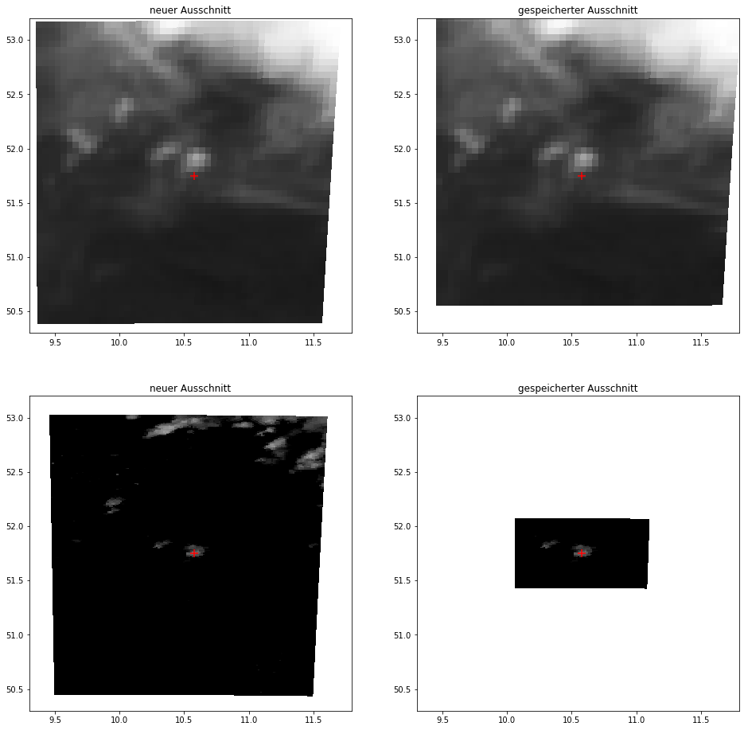

```python
xmin = 9.3
xmax = 11.8
ymin = 50.3
ymax = 53.2

fig,ax = plt.subplots(2,2,figsize = (16,16))
ax[0,0].pcolormesh(lon_cutout,lat_cutout,cutout,vmin=210,vmax=300,cmap='gray_r')
ax[0,0].set_title("neuer Ausschnitt")
ax[0,0].plot(punkt_lon,punkt_lat,'r+',markersize=10,mew=1.5)
ax[0,0].set_xlim(xmin,xmax)
ax[0,0].set_ylim(ymin,ymax)

ax[0,1].pcolormesh(track_data.lon.data,track_data.lat.data,track_data.ir108.data[6],vmin=210,vmax=300,cmap='gray_r')
ax[0,1].set_title("gespeicherter Ausschnitt")
ax[0,1].plot(punkt_lon,punkt_lat,'r+',markersize=10,mew=1.5)
ax[0,1].set_xlim(xmin,xmax)
ax[0,1].set_ylim(ymin,ymax)

ax[1,0].pcolormesh(rlon_cutout,rlat_cutout,cutout_radar,vmin=10,vmax=85,cmap='gray')
ax[1,0].set_title("neuer Ausschnitt")
ax[1,0].plot(punkt_lon,punkt_lat,'r+',markersize=10,mew=1.5)
ax[1,0].set_xlim(xmin,xmax)
ax[1,0].set_ylim(ymin,ymax)

ax[1,1].pcolormesh(track_data.rlon,track_data.rlat,track_data.z.data[6],vmin=10,vmax=85,cmap='gray')
ax[1,1].set_title("gespeicherter Ausschnitt")
ax[1,1].plot(punkt_lon,punkt_lat,'r+',markersize=10,mew=1.5)
ax[1,1].set_xlim(xmin,xmax)
ax[1,1].set_ylim(ymin,ymax)
```

Der gespeicherte Ausschnitt ist ein wenig noch Nordosten verschoben. Aber das könnte an der Parallaxenkorrektur liegen. Deshalb untersuchen wir den Einfluss der Parallaxenkorrektur.

```python
cth = msv.MSGtools.get_nwcsaf_prod('CTTH_HEIGHT',t_start,calibrate=True)
```

```python
import scipy.ndimage as ndi
```

```python
# smoothing
gauss_sig = 2
satlon= 9.5

cth_sm =  ndi.maximum_filter(cth, size = 3*gauss_sig)
cth_sm =  ndi.gaussian_filter(cth_sm, gauss_sig)

# do the parallax on coordiantes vector
plon, plat = px.parallax_correction(msg_lon, msg_lat, cth_sm, satlon = satlon)
```

```python
picol,pirow = mcc.ll2cl(plon,plat,'std','rss','oben')
```

```python
picol -= 1356
pirow -= 156
```

```python
f = s.bt['IR_108']
# prepare image warping
irow, icol = gi.make_index_set(*msg_lon.shape)

dirow = pirow - irow
dicol = picol - icol

ind =  np.array([irow - dirow, icol - dicol])

# image warping needs normalized fields
fmin = f.min()
fmax = f.max()
df = fmax - fmin

if df > 0:
    fnorm = (f - fmin) / df
else:
    fnorm = f - fmin

fn_warp = skimage.transform.warp(fnorm, ind, order = 3, mode = 'edge' )
# coordianet mapping also works
# bmap = scipy.ndimage.map_coordinates(h[itime], i)

f_warp = df * fn_warp + fmin
```

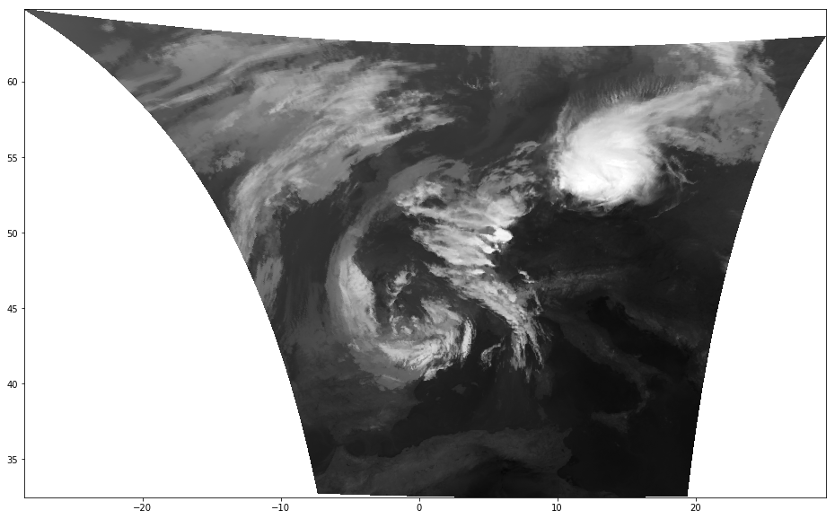

```python
fig,ax = plt.subplots(1,1,figsize=(16,10))
ax.pcolormesh(msg_lon,msg_lat,f_warp,vmin=210,vmax=300,cmap='gray_r')
```

```python
ausschnitt_neu = f_warp[r_radar-box_size:r_radar+box_size,
                        c_radar-box_size:c_radar+box_size]
```

```python
from mpl_toolkits.axes_grid1 import make_axes_locatable

def colourbar(mappable):
    ax = mappable.axes
    fig = ax.figure
    divider = make_axes_locatable(ax)
    cax = divider.append_axes("right", size="5%", pad=0.05)
    return fig.colorbar(mappable, cax=cax)
```

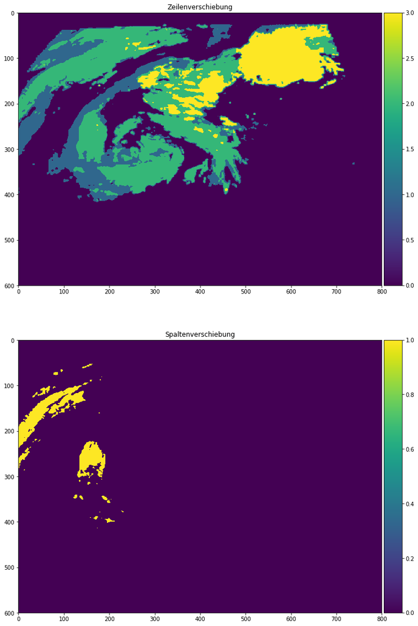

```python
fig,ax = plt.subplots(2,1,figsize=(16,20))
row_plot= ax[0].imshow(dirow)
ax[0].set_title("Zeilenverschiebung")
colourbar(row_plot)
col_plot= ax[1].imshow(dicol)
ax[1].set_title("Spaltenverschiebung")
colourbar(col_plot)
```

```
(50.3, 53.2)
```

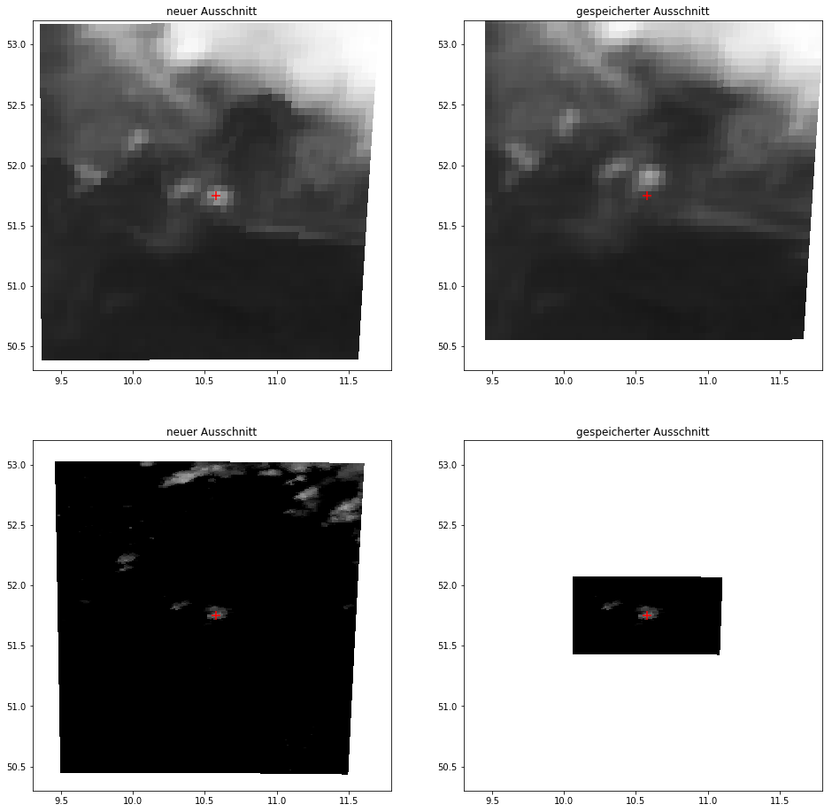

```python
xmin = 9.3
xmax = 11.8
ymin = 50.3
ymax = 53.2

fig,ax = plt.subplots(2,2,figsize = (16,16))
ax[0,0].pcolormesh(lon_cutout,lat_cutout,ausschnitt_neu,vmin=210,vmax=300,cmap='gray_r')
ax[0,0].set_title("neuer Ausschnitt")
ax[0,0].plot(punkt_lon,punkt_lat,'r+',markersize=10,mew=1.5)
ax[0,0].set_xlim(xmin,xmax)
ax[0,0].set_ylim(ymin,ymax)

ax[0,1].pcolormesh(track_data.lon.data,track_data.lat.data,track_data.ir108.data[6],vmin=210,vmax=300,cmap='gray_r')
ax[0,1].set_title("gespeicherter Ausschnitt")
ax[0,1].plot(punkt_lon,punkt_lat,'r+',markersize=10,mew=1.5)
ax[0,1].set_xlim(xmin,xmax)
ax[0,1].set_ylim(ymin,ymax)

ax[1,0].pcolormesh(rlon_cutout,rlat_cutout,cutout_radar,vmin=10,vmax=85,cmap='gray')
ax[1,0].set_title("neuer Ausschnitt")
ax[1,0].plot(punkt_lon,punkt_lat,'r+',markersize=10,mew=1.5)
ax[1,0].set_xlim(xmin,xmax)
ax[1,0].set_ylim(ymin,ymax)

ax[1,1].pcolormesh(track_data.rlon,track_data.rlat,track_data.z.data[6],vmin=10,vmax=85,cmap='gray')
ax[1,1].set_title("gespeicherter Ausschnitt")
ax[1,1].plot(punkt_lon,punkt_lat,'r+',markersize=10,mew=1.5)
ax[1,1].set_xlim(xmin,xmax)
ax[1,1].set_ylim(ymin,ymax)
```

Ist bei der vorherigen Parallaxenkorrektur oder dem Ausschnitt etwas schief gelaufen? Jedenfalls passt der neue Ansatz besser. Möglich ist auch, dass der Ausschnitt etwas anders aussieht, weil beim vorherigen Ansatz nur die linke untere Ecke des HACI-Ausschnittes einbezogen wurde.

```python
from plotting_tools.colormaps import enhanced_colormap2
emap = enhanced_colormap2()
```

```python
ctth_cutout = cth_sm[r_radar-box_size:r_radar+box_size,
                     c_radar-box_size:c_radar+box_size]
```

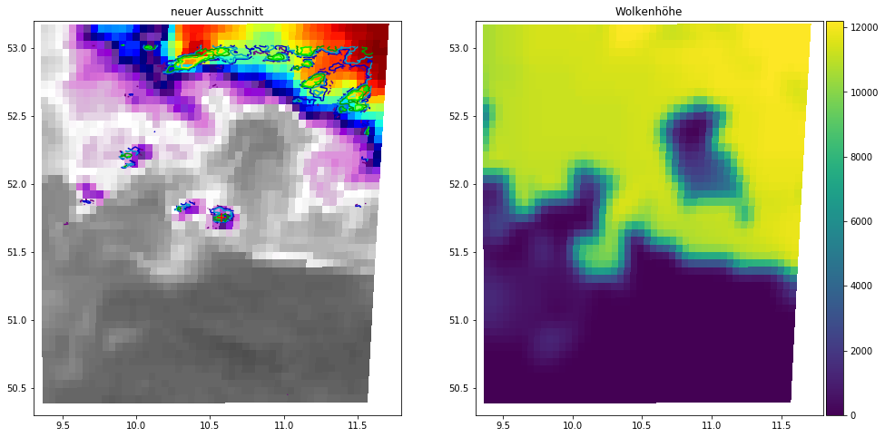

```python
xmin = 9.3
xmax = 11.8
ymin = 50.3
ymax = 53.2

fig,ax = plt.subplots(1,2,figsize = (16,8))
ax[0].pcolormesh(lon_cutout,lat_cutout,ausschnitt_neu,vmin=210,vmax=300,cmap=emap)
ax[0].set_title("neuer Ausschnitt")
ax[0].contour(rlon_cutout,rlat_cutout,np.ma.masked_less(cutout_radar,5),vmin=5,vmax=65,cmap='nipy_spectral')
ax[0].plot(punkt_lon,punkt_lat,'r+',markersize=10,mew=1.5)
ax[0].set_xlim(xmin,xmax)
ax[0].set_ylim(ymin,ymax)

ct_plot = ax[1].pcolormesh(lon_cutout,lat_cutout,ctth_cutout)
ax[1].set_title(u"Wolkenhöhe")
ax[1].set_xlim(xmin,xmax)
ax[1].set_ylim(ymin,ymax)
colourbar(ct_plot)
```

Das passt sogar ziemlich gut.

```python
def parallax_correct_msg(field,source_lon,source_lat,cloud_top_height,sat_res_id,sat_region_id,\
                         sat_scan_service_id,gauss_sig):
    """
    Do a parallax correction on the native MSG grid.

    Inputs:
    -------
    field: numpy array, 2d
        field to perform parallax correction for
    source_lon: numpy array, 2d, same shape as field
        longitude coordinates of the field pixels in degress
    source_lat: numpy array, 2d, same shape as field
        latitude coordinates of the field pixels in degrees
    cloud_top_height: numpy array, 2d same shape as field
        cloud top height of the field's pixels in meters
    sat_res_id: string, 'std' or 'hrv'
        identifier for the satellite resolution
    sat_region_id: string, e.g. 'eu'
        identifier for the used satellite region
    sat_scan_service_id: string, 'rss' or 'pts'
        identifier for the satellite scan intervall
    gauss_sig: int or float
        value parameter sigma of the 2d Gauß smoothing

    Returns:
    --------
    field_warped: numpy array, 2d
        field warped to the new coordinates
    """

    import scipy.ndimage as ndi
    import numpy as np
    import skimage

    from analysis_tools import parallax as px

    import l15_msevi.msevi_config as msvc

    import sys
    sys.path.append("/vols/talos/home/stephan/utils/")
    import msg_coord_conv as mcc

    # get satellite longitude
    _sat_longitudes = {'rss': 9.5,
                       'pzs': 0.0}

    sat_lon = _sat_longitudes[sat_scan_service_id]

    # smooth the cloud top height to achieve smoother parallax transformation
    cth_smooth =  ndi.maximum_filter(cloud_top_height, size = 3*gauss_sig)
    cth_smooth =  ndi.gaussian_filter(cth_smooth, gauss_sig)

    # do the parallax on coordiantes vector
    plon, plat = px.parallax_correction(source_lon, source_lat, cth_smooth, satlon = sat_lon)

    # convert the new geodetic coordinates into grid ones
    picol,pirow = mcc.ll2cl(plon,plat,sat_res_id,sat_scan_service_id,'oben')

    # correct the grid coordiantes by the region offsets
    region_id = "{}-{}".format(sat_region_id,sat_scan_service_id)

    col_offset = msvc._predefined_regions[region_id][1][0]
    row_offset = msvc._predefined_regions[region_id][0][0]

    pirow -= row_offset
    picol -= col_offset

    # prepare image warping
    irow, icol = gi.make_index_set(*source_lon.shape)

    dirow = pirow - irow
    dicol = picol - icol

    ind =  np.array([irow - dirow, icol - dicol])

    # image warping needs normalised fields
    fmin = field.min()
    fmax = field.max()
    df = fmax - fmin

    if df > 0:
        fnorm = (f - fmin) / df
    else:
        fnorm = f - fmin

    # warp image
    fn_warp = skimage.transform.warp(fnorm, ind, order = 3, mode = 'edge' )

    f_warp = df * fn_warp + fmin

    return f_warp
```

```python
test_px, chs = parallax_correct_msg(s.bt['IR_108'],msg_lon,msg_lat,cth,'std','eu','rss',1)
```

[output not shown]

```python
region_id = 'eu-rss'
msvc._predefined_regions[region_id]
```

```
((156, 756), (1356, 2156))
```

[figure not shown]

```python
fig,ax = plt.subplots(1,1,figsize=(16,10))
diff_plot = ax.imshow(f_warp - test_px,vmin=-0.1,vmax=0.1,cmap='RdBu_r')
plt.colorbar(diff_plot)
```

Die Funktion scheint zu passen.